# Markov chains

### **NOTES ON STATISTICS, PROBABILITY and MATHEMATICS**

### Transition or Stochastic Matrices and Discrete Time Markov Chains:

The objective of [Markov matrices](https://en.wikipedia.org/wiki/Stochastic_matrix) is to incorporate probability vectors so as to calculate the steady state distribution of proportions based on an initial state.

For example, if we know that a certain percentage of people leave the city for the suburbs every year, and a different proportion of city dwellers move to the suburbs, we can find out the percentage or number of people living in the city and suburbs one year from now:

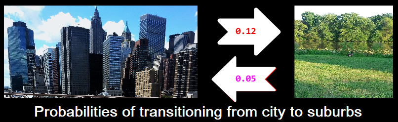

$$\begin{bmatrix}
& \text{City} & \text{Suburbs} \\
\text{City} & 0.88 & \color{red}{0.12}\\
\text{Suburbs} & \color{magenta}{0.05}
& 0.95\end{bmatrix}
\underbrace{\begin{bmatrix}\text{C}\\\text{S}\end{bmatrix}}_{\text{initial
state}}=\underbrace{\begin{bmatrix}\text{C}\\\text{S}\end{bmatrix}}_{\text{state
1 yr later}}$$

#### [ABSORBING MARKOV CHAINS](https://en.wikipedia.org/wiki/Absorbing_Markov_chain):

From [this series of lectures](https://youtu.be/BsOkOaB8SFk).

An absorbing state in a transition MC is such that when it is entered, it becomes impossible to leave. They are identified as $1$’s in the diagonal matrix.

An absorbing MC, like a regular MC, tends to a limiting matrix by calculating powers of the transition matrix, $P.$ The presence of absorbing states does not guarantee a limiting matrix: for its to happen, the absorbing states have to be able to transition to absorbing states.

For instance, in the matrix

$$\tiny P=\begin{bmatrix} & A & B
& C \\ A & 0 & 0 & 1 \\ B & 0 & 1 & 0 \\ C
& 1 & 0 & 0 \end{bmatrix}$$

has an absorbing state in $B$; however, it is impossible to reach from either $A$ or $C.$ Note that an absorbing state can be reach indirectly through other states.

A MC is an absorbing chain if 1. There is at least one absorbing state; and 2. It is possible to go from each non-absorbing states to at least one absorbing state in a finite number of steps.

Absorbing MC are organized in standard form with absorbing states in the upper-left block submatrix as an identity matrix.

Consider the following transition diagram:

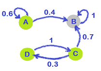

The standard form will be:

$$\small\begin{align}
P=\begin{bmatrix}
& \text{A} & \text{non-A}\\
\text{A} & I & 0 \\
\text{non-A}& R & Q
\end{bmatrix}
=
\begin{bmatrix}
& \text{B} & \text{A} & \text{C} & \text{D}\\
\text{B} &1 & 0 & 0 & 0 \\
\text{A} &.4 & .6 & 0 & 0 \\
\text{C} &.7 & 0 & 0 & .3 \\
\text{D} &0 & 0 & 1 & 0
\end{bmatrix}
\end{align}$$

Another example clarifies the block matrices. If we have a MC transition matrix given as

$$\small P=\begin{align}
\begin{bmatrix}
& \text{A} & \text{B} & \text{C} & \text{D}\\
\text{A} &0 & .3 & .3 & .4 \\
\text{B}
&0 & 1 & 0 & 0 \\
\text{C}
&0 & 0 & 1 & 0 \\
\text{D} &.8 & .1 & .1 & 0
\end{bmatrix}
\end{align}$$

can be written in standard form as

$$\small\begin{align}
P=\begin{bmatrix}
& \text{B} & \text{C} & \text{A} & \text{D}\\
\text{B} &1 & 0 & 0 & 0 \\
\text{C}
&0 & 1 & 0 & 0 \\
\text{A}
&.3 & .3 & 0 & .4 \\
\text{D} &.1 & .1 & .8 & 0
\end{bmatrix}
\end{align}$$

The matrix $R=\begin{bmatrix}.3&.3\\.1&.1\end{bmatrix}$ and the matrix $Q= \begin{bmatrix}0&.4\\.8&0\end{bmatrix}.$

The limiting matrix, $\bar P$ is approached as powers of the standard form of the absorbing MC $P^k$ when $k$ increases as

$$\bar P =\begin{bmatrix}
I& 0\\ FR & 0
\end{bmatrix}$$

where the block matrix $FR$ is calculated from the fundamental matrix $F=(I-Q)^{-1}.$’

The $R$ matrix is not necessarily square: if there are $n_a$ absorbing states, and $n_t$ transient states, the matrix $R$ will be $n_t \times n_a,$ and contain the transition probabilities between transient and absorbent states. On the other hand, $Q$ is square, $n_t \times n_t,$ containing the transition probabilities between transient states. The submatrix $I$ will be square $n_a \times n_a,$ and the matrix of zeroes will be square and $n_t \times n_t.$

##### Properties:

1. The entry in row $i$, column $j$ of $\bar P$ is the long-run probability of going from state $i$ to state $j.$
2. The sum of the entries in each row of the fundamental matrix $F$ is the average number of trials it takes to go from each non-absorbing state to some absorbing state.

##### Proof:

[This](https://www.ssc.wisc.edu/~jmontgom/absorbingchains.pdf) is a good resource. The submatrix $P$ contains the transition probabilities from transient to absorbing states, while $Q$ contains the transition probabilities from transient to transient states.

Powers of the transition matrix $P$ approach a limiting matrix with a pattern:

$$\begin{align}
P^2 &=\begin{bmatrix}I & 0 \\ R & Q \end{bmatrix}^2=
\begin{bmatrix}I & 0 \\ R+QR & Q^2 \end{bmatrix}\\[3ex]
P^3 &=\begin{bmatrix}I & 0 \\ R+QR & Q^2
\end{bmatrix}\begin{bmatrix}I & 0 \\ R & Q
\end{bmatrix}=\begin{bmatrix}I & 0 \\ R+QR+Q^2R & Q^3
\end{bmatrix}\\[3ex]
P^k &=\begin{bmatrix}I & 0 \\
\left(I+Q+Q^2+\cdots+Q^{k-1}\right)R & Q^k \end{bmatrix}\tag 1
\end{align}$$

The key now is that $Q^k\to 0$ as $k\to \infty.$

The fundamental matrix is a [geometric series](https://math.stackexchange.com/q/867768/152225):

$$F=
I+Q+Q^2+\cdots=(I-Q)^{-1}$$

and replacing the expression $I+Q+Q^2+\cdots+Q^{k-1}$ in (1) with $F:$

$$\begin{align}P^{\infty}&=\begin{bmatrix}I
& 0 \\ FR & 0 \end{bmatrix}\end{align}$$

##### Example problem:

Suppose a credit union classifies car loans into four categories: paid in full (F); in good standing (G); in arrears (A); or bad debt (B). Each month, $10\%$ of G accounts pay the loan in full; $80\%$ remain in G; and $10\%$ go to A. For accounts in A, $10\%$ are paid in full, $40\%$ become G; $40\%$ stay in A; and $10\%$ go to B:

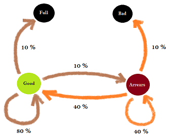

We want to know what percentage of accounts in A will default. And how many months the accounts in A will remain so, until they default or paid in full (the two absorbing states).

```r
(P = matrix(c(1,0,0,0,0,1,0,0,.1,0,.8,.1,.1,.1,.4,.4), nrow=4, byrow=T))
```

```
##      [,1] [,2] [,3] [,4]
## [1,]  1.0  0.0  0.0  0.0
## [2,]  0.0  1.0  0.0  0.0
## [3,]  0.1  0.0  0.8  0.1
## [4,]  0.1  0.1  0.4  0.4
```

```r
(R = P[3:4, 1:2])
```

```
##      [,1] [,2]
## [1,]  0.1  0.0
## [2,]  0.1  0.1
```

```r
(Q = P[3:4, 3:4])
```

```
##      [,1] [,2]
## [1,]  0.8  0.1
## [2,]  0.4  0.4
```

```r
(Fund = solve(diag(2) - Q))
```

```
##      [,1] [,2]
## [1,]  7.5 1.25
## [2,]  5.0 2.50
```

```r
(FR = Fund %*% R)
```

```
##       [,1]  [,2]
## [1,] 0.875 0.125
## [2,] 0.750 0.250
```

Just reading from the last matrix, $75\%$ of accounts in arrears (last row) will be paid in full (F), and $25\%$ will ultimately default. Likewise, of the good (G) accounts $87\%$ will ultimately be paid in full, and $13\%$ will default (B).

The average of months the accounts in A will remain in A before reaching an absorbing state (either F or B) will be

```r
rowSums(Fund)[2]
```

```
## [1] 7.5
```

That is, an average of $7.5$ months until they are paid in full, or go into default.

The interpretation of the entries of the fundamental matrix, `Fund`, or $F$ in general is as follows: $F(i,j)$ is the number of periods (in this case, months) spent in the $j$ non-absorbing state when the chain started in the $i$ non-absorbing state. And $\sum_j F(i,j)$ yields the expected number of period spent in any non-absorbing state, given that we started at state $i,$ which is the calculation of $7.5$ months in the example above.

##### Proof:

Since

$$F = (I- Q)^{-1}= I + Q + Q^2
+\cdots$$

$$F(i,j) = Q^0(i,j) + Q^1(i,j) +
Q^2(i,j)+\cdots$$

where $Q^t(i,j)$ is that the probability that the process that started in the $i$ non-absorbing state will be in the $j$ non-absorbing state at time $t.$ Or intepreted differently, the fraction of period $t$ spent in state $j.$ Therefore, the sum over all periods is the expected periods spent in $j.$

Finally, going back to the transition diagram above, all initial states will be unavoidably absorbed into B:

```r
(P = matrix(c(1,0,0,0,.4,.6,0,0,.7,0,0,.3,0,0,1,0), nrow=4, byrow=T))
```

```
##      [,1] [,2] [,3] [,4]
## [1,]  1.0  0.0    0  0.0
## [2,]  0.4  0.6    0  0.0
## [3,]  0.7  0.0    0  0.3
## [4,]  0.0  0.0    1  0.0
```

```r
R = P[2:4, 1, drop=F]
Q = P[2:4, 2:4]
Fund = solve(diag(3) - Q)
(FR = Fund %*% R)
```

```
##      [,1]
## [1,]    1
## [2,]    1
## [3,]    1
```

```r
(P = matrix(c(1,0,0,0,0,1,0,0,.1,0,.8,.1,.1,.1,.4,.4), nrow=4, byrow=T))
```

```
##      [,1] [,2] [,3] [,4]
## [1,]  1.0  0.0  0.0  0.0
## [2,]  0.0  1.0  0.0  0.0
## [3,]  0.1  0.0  0.8  0.1
## [4,]  0.1  0.1  0.4  0.4
```

After the second month…

```r
P%*%P
```

```
##      [,1] [,2] [,3] [,4]
## [1,] 1.00 0.00 0.00 0.00
## [2,] 0.00 1.00 0.00 0.00
## [3,] 0.19 0.01 0.68 0.12
## [4,] 0.18 0.14 0.48 0.20
```

there’ll be a lot of accounts in the transient states. But after six years there is no account in the transition states, having all been absorbed (notice the empty lower-right corner block matrix:

```r
require(expm)
round(P %^% 75, 3)
```

```
##       [,1]  [,2] [,3] [,4]
## [1,] 1.000 0.000    0    0
## [2,] 0.000 1.000    0    0
## [3,] 0.875 0.125    0    0
## [4,] 0.750 0.250    0    0
```

#### Markov Chains and Ergodicity:

From [this post](https://twitter.com/normonics/status/1509234405222535180?s=20&t=rONOhathYVTHj9zam7aJTw) on Twitter by @normonics.

There were Markov chains without absorbing states that are non-ergodic, such as a simple random walk.

Conditions for **ergodicity**:

From [this presentation](https://youtu.be/YrTeOrRF0XA).

##### **Irreducibility**:

From any state it is possible to get to any state.

In a Markov transition matrix $P$ with $N$ states all the entries in
$$\sum_{n=0}^{N-1} P^n$$

must be $>0$ for the matrix to be irreducible. Why? Because for any given $P^n$ the enty $ij$ is the probability of reaching state $j$ from state $i$ in $n$ steps. The summation of these powers will tell us that if the entries are greater that zero **at least in one number of the steps** $n$ there is a a path (i.e. probability of greater than zero of that transition happening in $n$ steps). We want this to be true for all states.

If there is a possibility of going from one state to another in a system with $N$ states, that will occur in a maximum of $N-1$ steps.

##### **Aperiodicity**:

The paths from one state to itself $i \to i=ii$ are not only multiples of a period $T \geq 2.$ It can be checked by finding a loop in the transition diagram of $k$ steps, and another loop of $k+1$ steps. Once is enough if irreducible. With transition matrices: Find $k$ and $i$ such that
$$P^k_{ii}P^{k+1}_{ii}>0.$$

This means that there is a probability greater than zero of going from $i \to i$ in $k$ steps, and also positive in $k+1$ steps.

We check the diagonal matrix entries in two consecutive powers.

The idea is that we want to reach a steady-state vector of strictly positive probabilities independent of where we start.

##### **Positive recurrence**:

If I am at a given state the expected time before returning to that state is finite. If the matrix is irreducible and the number of states is finite, it is automatically fulfilled.

##### Example:

##### Non-ergodic periodic chain:

```r
library(expm)
# Example 1 -> 2 -> 3 -> 1
mat <- matrix(c(0,1,0,0,0,1,1,0,0),ncol=3,byrow=T)
mat
```

```
##      [,1] [,2] [,3]
## [1,]    0    1    0
## [2,]    0    0    1
## [3,]    1    0    0
```

A state $i$ is absorbing if once the system reaches state $i,$ it stays in that state; that is, $\Pr_{ii}=1$. There are no $1$’s in the diagonal in this matrix.

Checking irreducibility:

```r
# Irreducible:
M <- matrix(rep(0,9),ncol=3)
for (i in 0:2) M <- M + mat %^% i
M
```

```
##      [,1] [,2] [,3]
## [1,]    1    1    1
## [2,]    1    1    1
## [3,]    1    1    1
```

It is irreducible because all values are positive.

But it is not aperiodic because there are no two consecutive powers with any one diagonal entry positive in those consecutive powers:

```r
# Aperiodic:
# Example: 1 -> 2 -> 3 -> 1
# If we want to move from 1 to itself we can do it in 3 steps or 6 or 9 or 12... So it's periodic with T = 3.
mat %^% 1
```

```
##      [,1] [,2] [,3]
## [1,]    0    1    0
## [2,]    0    0    1
## [3,]    1    0    0
```

```r
mat %^% 2
```

```
##      [,1] [,2] [,3]
## [1,]    0    0    1
## [2,]    1    0    0
## [3,]    0    1    0
```

```r
mat %^% 3
```

```
##      [,1] [,2] [,3]
## [1,]    1    0    0
## [2,]    0    1    0
## [3,]    0    0    1
```

```r
mat %^% 4
```

```
##      [,1] [,2] [,3]
## [1,]    0    1    0
## [2,]    0    0    1
## [3,]    1    0    0
```

```r
# P to the power of 3 is the identity. Same for any P to the power of 1 + 3k or 2 + 3k or 3 + 3k.
```

This matrix is non-ergotic.

##### Non-ergodic chain with no absorbing state:

```r
trans_mat <- matrix(c(0,1/2,0,1/2,0,
                      0,1/2,1/2,0,0,
                      0,1/2,1/2,0,0,
                      0,0,0,1/2,1/2,
                      0,0,0,1/2,1/2),ncol=5,byrow=T)
N = 100
trans_mat %^% N
```

```
##      [,1] [,2] [,3] [,4] [,5]
## [1,]    0 0.25 0.25 0.25 0.25
## [2,]    0 0.50 0.50 0.00 0.00
## [3,]    0 0.50 0.50 0.00 0.00
## [4,]    0 0.00 0.00 0.50 0.50
## [5,]    0 0.00 0.00 0.50 0.50
```

We try to find an absorbing state (i.e. a $1$ in any entry) with a very high number of steps $N = 100,$ and it doesn’t happen: no absorbing states.

```r
# Check lack of irreducibility... number of states is 5:

M <- matrix(rep(0,25),ncol=5)
for (i in 0:4) M <- M + trans_mat %^% i
M
```

```
##      [,1] [,2] [,3] [,4] [,5]
## [1,]    1 1.25 0.75 1.25 0.75
## [2,]    0 3.00 2.00 0.00 0.00
## [3,]    0 2.00 3.00 0.00 0.00
## [4,]    0 0.00 0.00 3.00 2.00
## [5,]    0 0.00 0.00 2.00 3.00
```

Not all states are greater than $0$ and therefore, the chain is not irreducible (hence, non-ergotic).

##### Non-ergodic chain with no absorbing state and each state with at least one incoming state:

```r
trans_mat <- matrix(c(0,1/2,0,1/2,0,
                      0,1/2,1/2,0,0,
                      0,1/2,1/2,0,0,
                      0,0,0,1/2,1/2,
                      1/10,0,0,4/10,1/2),ncol=5,byrow=T)
N = 100
trans_mat %^% N
```

```
##             [,1]      [,2]      [,3]       [,4]       [,5]
## [1,] 0.002145419 0.4790818 0.4779816 0.01987296 0.02091818
## [2,] 0.000000000 0.5000000 0.5000000 0.00000000 0.00000000
## [3,] 0.000000000 0.5000000 0.5000000 0.00000000 0.00000000
## [4,] 0.004183637 0.4592089 0.4570634 0.03875293 0.04079114
## [5,] 0.003974592 0.4612471 0.4592089 0.03681655 0.03875293
```

We try to find an absorbing state (i.e. a $1$ in any entry) with a very high number of steps $N = 100,$ and it doesn’t happen: no absorbing states.

Checking irreducibility:

```r
M <- matrix(rep(0,25),ncol=5)
for (i in 0:4) M <- M + trans_mat %^% i
M
```

```
##        [,1]   [,2]   [,3]   [,4]   [,5]
## [1,] 1.0500 1.2625 0.7500 1.2000 0.7375
## [2,] 0.0000 3.0000 2.0000 0.0000 0.0000
## [3,] 0.0000 2.0000 3.0000 0.0000 0.0000
## [4,] 0.1475 0.0625 0.0125 2.8400 1.9375
## [5,] 0.2400 0.1600 0.0625 1.6975 2.8400
```

The matrix is not irreducible.

##### Ergodic chain:

```r
trans_mat <- matrix(c(0,1/2,0,1/2,0,
                      0,1/2,1/2,0,0,
                      1/10,4/10,5/10,0,0,
                      0,0,0,1/2,1/2,
                      1/10,0,0,4/10,1/2),ncol=5,byrow=T)
N = 100
trans_mat %^% N
```

```
##            [,1]      [,2]      [,3]      [,4]      [,5]
## [1,] 0.04761905 0.2380952 0.2380952 0.2380952 0.2380952
## [2,] 0.04761905 0.2391986 0.2393289 0.2369918 0.2368616
## [3,] 0.04761905 0.2390821 0.2391986 0.2371083 0.2369918
## [4,] 0.04761905 0.2369918 0.2368616 0.2391986 0.2393289
## [5,] 0.04761905 0.2371083 0.2369918 0.2390821 0.2391986
```

Checking irreducibility:

```r
M <- matrix(rep(0,25),ncol=5)
for (i in 0:4) M <- M + trans_mat %^% i
M
```

```
##        [,1]   [,2]   [,3]   [,4]   [,5]
## [1,] 1.1000 1.2125 0.7375 1.2125 0.7375
## [2,] 0.1475 2.8400 1.9375 0.0625 0.0125
## [3,] 0.2425 1.6975 2.8400 0.1575 0.0625
## [4,] 0.1475 0.0625 0.0125 2.8400 1.9375
## [5,] 0.2425 0.1575 0.0625 1.6975 2.8400
```

Checking aperiodicity:

```r
trans_mat %^% 3
```

```
##       [,1]  [,2]  [,3]  [,4]  [,5]
## [1,] 0.050 0.225 0.250 0.225 0.250
## [2,] 0.050 0.450 0.475 0.025 0.000
## [3,] 0.045 0.430 0.450 0.050 0.025
## [4,] 0.050 0.025 0.000 0.450 0.475
## [5,] 0.045 0.050 0.025 0.430 0.450
```

```r
trans_mat %^% 4
```

```
##        [,1]   [,2]   [,3]   [,4]   [,5]
## [1,] 0.0500 0.2375 0.2375 0.2375 0.2375
## [2,] 0.0475 0.4400 0.4625 0.0375 0.0125
## [3,] 0.0475 0.4175 0.4400 0.0575 0.0375
## [4,] 0.0475 0.0375 0.0125 0.4400 0.4625
## [5,] 0.0475 0.0575 0.0375 0.4175 0.4400
```

There are multiple diagonal terms positive in both consecutive powers.

[Home Page](http://rinterested.github.io/statistics/index.html)

**NOTE: These are tentative notes on different topics for personal use - expect mistakes and misunderstandings.**